# Foreign Professionals: U.S. Tech’s Other Pipelines – Version 1.0a

Roy L Beasley, PhD – DLL Editor

1/6/17

## Overview

Top managers claim that American firms in the U.S. technology sector employ foreign professionals because they cannot find enough qualified American techs in the domestic job pipelines. This supplement uses Census data to estimate the employment of foreign techs in the 50 states plus the District of Columbia in 2015 and to estimate the increase in the employment of foreign techs between 2010 and 2015.

*Please note that all of the numbers in this overview and in the subsequent sections of this supplement are estimates based on U.S. Census survey samples. Accordingly all numbers should be read as “approximately” even when the word “approximately” does not appear.*

- In 2015, there were approximately 4,636,487 professionals in the U.S. tech sector; 4,066,773 were Americans (87.7 percent); 569,714 were foreign (12.3 percent, Table 1C).
- In 2015 approximately 80% of foreign techs were male; 20% were female; 15.7% of foreign techs were female techs who came from Asian countries; and 4.3% were female techs from non-Asian countries. (Chart 5 and Table 2C)

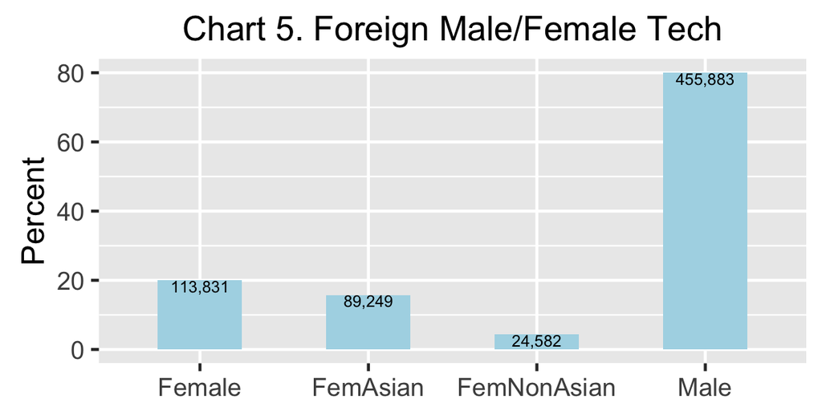

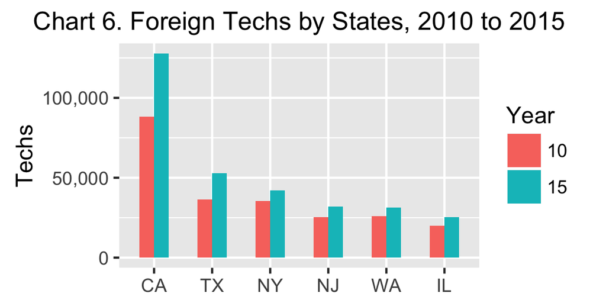

- Employment of foreign techs in the 50 states plus the District of Columbia increased by 32.7 percent between 2010 and 2015 (Table 3EE). By contrast, employment of American techs only increased by 22.4 percent (Table 3ZZ) during that time frame.
- In recent years cloud computing and machine learning became principal drivers in the expansion of the U.S. tech sector. Therefore contrasts between the increase in American vs. foreign tech employment in three job categories are especially noteworthy ==> software developers, database administrators, and computer/research scientists.
- American firms increased their employment of foreign software developers from 187,359 in 2010 to 266,807 in 2015, i.e., a 42.4 percent increase (Table 3EE). American firms increased their employment of American software developers by only 37 percent between 2010 and 2015 (Table 3ZZ)
- American firms increased their employment of foreign database administrators from 9,250 in 2010 to 14,069 in 2015, i.e, a 52.1 percent increase (Table 3EE). American firms increased their employment of American database admiistrators by only 4.6 percent between 2010 and 2015 (Table 3ZZ)
- American firms increased their employment of foreign computer/research scientists from 2,183 in 2010 to 3,752 in 2015, i.a., a 71.9 percent increase (Table 3EE). American firms increased their employment of American computer/research scientists by only 13.3 percent between 2010 and 2015 (Table 3ZZ)
- In 2015 California employed the largest number of foreign techs in all three categories ==> software developers = 74,399; database administrators = 2,650; and computer/research scientists = 993. California also recruited the largest increases in foreign techs between 2010 and 2015 ==> software developers = 27,147 … database administrators = 2,133 … and computer/research scientists = 425 (Table 3F)

These estimates of substantial employment of foreign techs in 2015 and substantial increases in the employment of foreign techs between 2010 and 2015 were consistent with managers’ claims that they were using foreign job pipelines to cover shortfalls in the availability of qualified American techs in the domestic job pipelines.

But it must be noted that substantial increases in the employment of foreign techs were also consistent with an alternative interpretation, i.e., that American managers were importing foreign labor because it was cheaper than American labor. In other words domestic job pipelines did not contain enough American techs who were willing to work for the lower salaries that were acceptable to foreign techs. This is not to say that foreign techs were paid salaries that were below the salary ranges paid to American techs, merely that larger numbers of foreign techs were willing to work for salaries that were at the lower end of the salary ranges offered to American techs.

Only a small percentage of the top managers in any economic sector are “disruptors” or “innovators”. Most tend to implement “best practices” as identified by whatever the most successful top managers in their sectors are doing. In the case of U.S. tech, the most successful top managers are in California, and California’s tech sector employs a much higher percentage of foreign techs than the tech sectors in other states. So that’s what we should expect the top managers in the tech sectors of other states will do in the next five years ==> employ higher percentages of foreign techs.

**Unfortunately, assigning larger and larger percentages of the jobs in U.S. tech to foreign professionals conflicts with the public commitments of the sector’s top managers to make tech more diversified by hiring larger percentages of Black and Hispanic professionals.**

[back-to-top](https://archimedes2kxx.github.io/BestStatesForBlackTech/Supplement-3.html)

## Findings

Brief answers to the first two questions provide a framwork for the extended responses to the third and fourth questions that form the core of this supplement.

*Note: The tables, maps, and charts in this supplement about foreign techs have been assigned numbers that follow the numbers of similar tables, maps, and charts in the original report about American techs. For example, Tables 3E and 3F appear in ths supplement because Tables 3A, 3B, 3C, and 3D appeared in the original. On the other hand a few tables from the original are repeated in this supplement as convenient references for the reader and are assigned the same numbers as in the original; for example, Tables 1C and 1E.*

*Note: The appearance of zeros in most tables should not be interpreted as literal zeros, but as standins for missing values wherever the Census sample was too small to enable reliable estimates.*

#### Question 1 – How many foreign professionals worked in the U.S. tech sector in 2015?

*Answer 1C* … As can be seen from Table 1C (below), 12.3 percent of the employees in the U.S. tech sector in 2015 were foreign professionals, a small increase over the 11.4 percent share held by foreign professionals in 2010.

**Table 1C – American and Foreign Components of the U.S. Tech Sector in 2010 and 2015**

```
    Total2010 Citizens2010 Foreign2010 Total2015 Citizens2015 Foreign2015
Num 3,751,376 3,322,079    429,297     4,636,487 4,066,773    569,714
Per 100       88.6         11.4        100       87.7         12.3
```

*Question 1E* – How many Asian and non-Asian foreign employees were in U.S. tech in the 50 states plus the District of Columbia in 2015?

*Answer 1E* … As per Table 1E (below), there were more than twice as many foreign professionals from Asian countries as from other countries in U.S. tech in 2015.

**Table 1E – Foreign Asian and Non-Asian Components of the U.S. Tech Sector in 2015**

```
    Total   Asian   NonAsian
Num 569,714 407,481 162,233
Per 100     71.5    28.5
```

[back-to-top](https://archimedes2kxx.github.io/BestStatesForBlackTech/Supplement-3.html)

#### Question 2 – What was the foreign male/female composition of U.S. tech in 2015?

**Table 2C – Foreign Male/Female Components of the U.S. Tech Sector in 2015**

```
    Total   Male    Female  FemAsian FemNonAsian
Num 569,714 455,883 113,831 89,249   24,582
Per 100     80      20      15.7     4.3
```

[back-to-top](https://archimedes2kxx.github.io/BestStatesForBlackTech/Supplement-3.html)

#### Question 3 – How did the foreign shares of jobs in U.S. tech change between 2010 and 2015?

*Answer 3* … The first two tables in this section, Table 3Z and Tables 3ZZ, were copied from the original report. They provide profiles of the jobs held by American professionals in the U.S. tech sector. Subsequent tables in this section provide increasingly detailed profiles of the jobs held by foreign professionals. These foreign profiles can be interpreted as specific measures of the substantial shortfalls in the supply of American techs. Alternatively, they can be also interpreted as specific measures of the extent to thich American managers imported cheaper labor from foreign sources than was available from the nation’s domestic pipelines.

This supplement defined “information technology” by using the same thirteen standard occupation categories (SOC) as in the original report. Twelve categories were related to software, e.g., Software Developers and Computer Programmers; one related to hardware, i.e., Computer Hardware Engineers.

[back-to-top](https://archimedes2kxx.github.io/BestStatesForBlackTech/Supplement-3.html)

**American Female vs. Foreign Female Techs in 2010 and 2015 … Tables 3Z/3ZZ vs Tables 3E/3EE**

- U.S. tech employed more foreign female professionals in 2015 than in 2010. Nevertheless, the percentage of the foreign tech workforce that was female declined from 21.6% in 2010 down to 20% in 2015 (Tables 3E and 3EE). A similar decline in the female component of the American tech workforce also occurred, from 27.1% in 2010 down to 25.6% in 2015 (Tables 3Z and 3ZZ).
- In recent years cloud computing and machine learning became principal drivers in the expansion of the U.S. tech sector. Therefore contrasts between the increase in American vs. foreign tech employment in three job categories are especially noteworthy ==> software developers, database administrators, and computer/research scientists.
- The percentage of the foreign female software developers declined from 21.1% in 2010 down to 19.5% in 2015 (Tables 3E and 3EE). The female component of American software developers also declined, from 22% in 2010 down to 20.3% in 2015 (Tables 3Z and 3ZZ).
- The percentage of the foreign female database administrators declined from 32% in 2010 down to 23.8% in 2015 (Tables 3E and 3EE). The female component of American database administrators also declined, from 39.8% in 2010 down to 37.1% in 2015 (Tables 3Z and 3ZZ).
- The percentage of the foreign female computer/research scientists declined from 26.5% in 2010 down to 10.3% in 2015 (Tables 3E and 3EE). The female component of the American computer/research scientists also declined, from 39.8% in 2010 down to 29.9% in 2015 (Tables 3Z and 3ZZ).
- These declines in female shares of both the foreign and American components of the U.S. tech workforce in all three critical areas might be explained by domestic and global shortages of qualified female techs … Or these declines might reflect gender bias among U.S. managers against hiring female techs, a bias that transcended the female techs’ status as foreigners or as citizens.

[back-to-top](https://archimedes2kxx.github.io/BestStatesForBlackTech/Supplement-3.html)

**Table 3Z – American Male/Female Composition of U.S. Tech in 2015**

```
                     Occupation perTS    Tech15       Fem perF15
                All Occupations 100.0 4,066,773 1,039,074   25.6
            SOFTWARE DEVELOPERS  22.2   903,442   183,800   20.3
   COMPUTER SUPPORT SPECIALISTS  14.6   594,490   147,645   24.8
 COMPUTER OCCUPATIONS ALL OTHER  13.1   532,369   128,808   24.2
 COMPUTER/INFO SYSTEMS MANAGERS  13.0   527,801   153,180   29.0
      COMPUTER SYSTEMS ANALYSTS  10.5   425,677   169,390   39.8
           COMPUTER PROGRAMMERS   9.5   386,212    82,890   21.5
    NETWORK/COMP SYSTEMS ADMINS   4.8   196,517    36,571   18.6
                 WEB DEVELOPERS   4.4   177,299    65,555   37.0
        DATABASE ADMINISTRATORS   2.4    99,523    36,896   37.1
    COMPUTER NETWORK ARCHITECTS   2.4    97,108     8,239    8.5
  INFORMATION SECURITY ANALYSTS   1.6    64,555    14,336   22.2
    COMPUTER HARDWARE ENGINEERS   1.1    45,238     6,811   15.1
  COMP/INFO RESEARCH SCIENTISTS   0.4    16,542     4,953   29.9
```

**Table 3ZZ – Changes in the American Composition of U.S. Tech Between 2010 and 2015**

```
                     Occupation    Tech10    Tech15  Change perCh perF10
                All Occupations 3,322,079 4,066,773 744,694  22.4   27.1
            SOFTWARE DEVELOPERS   659,612   903,442 243,830  37.0   22.0
   COMPUTER SUPPORT SPECIALISTS   483,108   594,490 111,382  23.1   28.5
 COMPUTER OCCUPATIONS ALL OTHER   284,682   532,369 247,687  87.0   23.8
 COMPUTER/INFO SYSTEMS MANAGERS   447,877   527,801  79,924  17.8   32.3
      COMPUTER SYSTEMS ANALYSTS   400,925   425,677  24,752   6.2   37.2
           COMPUTER PROGRAMMERS   402,970   386,212 -16,758  -4.2   23.2
    NETWORK/COMP SYSTEMS ADMINS   209,298   196,517 -12,781  -6.1   18.9
                 WEB DEVELOPERS   144,466   177,299  32,833  22.7   36.0
        DATABASE ADMINISTRATORS    95,143    99,523   4,380   4.6   39.8
    COMPUTER NETWORK ARCHITECTS    84,261    97,108  12,847  15.2    8.9
  INFORMATION SECURITY ANALYSTS    45,484    64,555  19,071  41.9   25.9
    COMPUTER HARDWARE ENGINEERS    49,655    45,238  -4,417  -8.9   14.2
  COMP/INFO RESEARCH SCIENTISTS    14,598    16,542   1,944  13.3   39.8
```

[back-to-top](https://archimedes2kxx.github.io/BestStatesForBlackTech/Supplement-3.html)

**Table 3E – Foreign Male/Female Composition of U.S. Tech in 2015**

```
                     Occupation perTS  Tech15     Fem perF15
                All Occupations 100.0 569,714 113,831   20.0
            SOFTWARE DEVELOPERS  46.8 266,807  51,931   19.5
      COMPUTER SYSTEMS ANALYSTS   9.4  53,269  13,328   25.0
           COMPUTER PROGRAMMERS   9.1  52,082  10,223   19.6
 COMPUTER/INFO SYSTEMS MANAGERS   8.7  49,546   6,900   13.9
 COMPUTER OCCUPATIONS ALL OTHER   7.9  45,020   9,618   21.4
   COMPUTER SUPPORT SPECIALISTS   7.6  43,017   8,756   20.4
        DATABASE ADMINISTRATORS   2.5  14,069   3,351   23.8
                 WEB DEVELOPERS   2.0  11,193   4,045   36.1
    NETWORK/COMP SYSTEMS ADMINS   2.0  11,149   1,828   16.4
    COMPUTER NETWORK ARCHITECTS   1.9  10,909   1,258   11.5
    COMPUTER HARDWARE ENGINEERS   1.2   6,979   1,677   24.0
  COMP/INFO RESEARCH SCIENTISTS   0.7   3,752     387   10.3
  INFORMATION SECURITY ANALYSTS   0.3   1,922     529   27.5
```

**Table 3EE – Changes in the Foreign Composition of U.S. Tech Between 2010 and 2015**

```
                     Occupation  Tech10  Tech15  Change perCh perF10
                All Occupations 429,297 569,714 140,417  32.7   21.6
            SOFTWARE DEVELOPERS 187,359 266,807  79,448  42.4   21.1
      COMPUTER SYSTEMS ANALYSTS  57,571  53,269  -4,302  -7.5   25.1
           COMPUTER PROGRAMMERS  52,377  52,082    -295  -0.6   22.5
 COMPUTER/INFO SYSTEMS MANAGERS  35,164  49,546  14,382  40.9   16.7
 COMPUTER OCCUPATIONS ALL OTHER  19,406  45,020  25,614 132.0   20.6
   COMPUTER SUPPORT SPECIALISTS  25,045  43,017  17,972  71.8   23.6
        DATABASE ADMINISTRATORS   9,250  14,069   4,819  52.1   32.0
                 WEB DEVELOPERS   8,895  11,193   2,298  25.8   27.1
    NETWORK/COMP SYSTEMS ADMINS  13,719  11,149  -2,570 -18.7   13.7
    COMPUTER NETWORK ARCHITECTS   8,335  10,909   2,574  30.9   10.7
    COMPUTER HARDWARE ENGINEERS   8,549   6,979  -1,570 -18.4   24.5
  COMP/INFO RESEARCH SCIENTISTS   2,183   3,752   1,569  71.9   26.5
  INFORMATION SECURITY ANALYSTS   1,444   1,922     478  33.1   20.3
```

[back-to-top](https://archimedes2kxx.github.io/BestStatesForBlackTech/Supplement-3.html)

**Key Jobs for American and foreign techs … Table 3F**

For more convenient reference, extracts of data from Tables 3ZZ and 3EE about the three key job categories appear in the labelled sections of Table 3F (below). The first section displays data about American techs in 2010 and 2015; the second shows data about foreign techs; the third about their combined American and foreign totals; and the fourth shows the percentage of these critical jobs that were held by foreign techs:

- Employment of foreign techs in all occupations increased by 32.7 percent between 2010 and 2015 (Table 3F.For). By contrast, employment of American techs only increased by 22.4 percent (Table 3F.Cit) during that time frame.
- U.S. tech increased its employment of foreign software developers from 187,359 in 2010 to 266,807 in 2015, i.e., a 42.4 percent increase (Table 3F.For). U.S. tech increased its employment of American software developers by only 37 percent between 2010 and 2015 (Table 3F.Cit)
- U.S. tech increased its employment of foreign database administrators from 9,250 in 2010 to 14,069 in 2015, i.e, a 52.1 percent increase (Table 3F.For). U.S. tech increased its employment of American database admiistrators by only 4.6 percent between 2010 and 2015 (Table 3F.Cit)
- U.S. tech increased its employment of foreign computer/research scientists from 2,183 in 2010 to 3,752 in 2015, i.a., a 71.9 percent increase (Table 3F.For). U.S. tech increased its employment of American computer/research scientists by only 13.3 percent between 2010 and 2015 (Table 3F.Cit)
- That foreign employment in U.S. tech grew faster than American employment had the inevitable consequence that the foreign share of U.S. tech grew larger between 2010 and 2015. The 2010 and 2015 percentages are displayed in Table 3F.perFor (below).

**Table 3F.Cit – Key Jobs for American Techs**

```
                    Occupation    Tech10    Tech15  Change perCh
               All Occupations 3,322,079 4,066,773 744,694  22.4
           SOFTWARE DEVELOPERS   659,612   903,442 243,830  37.0
       DATABASE ADMINISTRATORS    95,143    99,523   4,380   4.6
 COMP/INFO RESEARCH SCIENTISTS    14,598    16,542   1,944  13.3
```

**Table 3F.For – Key Jobs for Foreign Techs**

```
                    Occupation  Tech10  Tech15  Change perCh
               All Occupations 429,297 569,714 140,417  32.7
           SOFTWARE DEVELOPERS 187,359 266,807  79,448  42.4
       DATABASE ADMINISTRATORS   9,250  14,069   4,819  52.1
 COMP/INFO RESEARCH SCIENTISTS   2,183   3,752   1,569  71.9
```

**Table 3F.Tot – Combined Total of Key Jobs Held by American and Foreign Techs**

```
                    Occupation    Tech10    Tech15
               All Occupations 3,751,376 4,636,487
           SOFTWARE DEVELOPERS   846,971 1,170,249
       DATABASE ADMINISTRATORS   104,393   113,592
 COMP/INFO RESEARCH SCIENTISTS    16,781    20,294
```

**Table 3F.perFor – Percentage of Key Jobs Held by Foreign Techs**

```
                    Occupation per2010 per2015
               All Occupations    11.4    12.3
           SOFTWARE DEVELOPERS    22.1    22.8
       DATABASE ADMINISTRATORS     8.9    12.4
 COMP/INFO RESEARCH SCIENTISTS    13.0    18.5
```

[back-to-top](https://archimedes2kxx.github.io/BestStatesForBlackTech/Supplement-3.html)

**Key Jobs for foreign techs in states employing the most foreign techs … Table 3G**

[back-to-top](https://archimedes2kxx.github.io/BestStatesForBlackTech/Supplement-3.html)

**Table 3G – Key Jobs for Foreign Techs in States Employing the Most Foreign Techs**

```
                    Occupation  Tech10  Tech15  Change  perCh       State
               All Occupations 429,297 569,714 140,417   32.7 All Foreign
               All Occupations  88,122 127,671  39,549   44.9  California
               All Occupations  36,327  52,885  16,558   45.6       Texas
               All Occupations  35,337  42,075   6,738   19.1    New York
               All Occupations  25,463  31,859   6,396   25.1  New Jersey
               All Occupations  25,883  31,201   5,318   20.5  Washington
               All Occupations  19,943  25,359   5,416   27.2    Illinois
 COMP/INFO RESEARCH SCIENTISTS   2,183   3,752   1,569   71.9 All Foreign
 COMP/INFO RESEARCH SCIENTISTS     568     993     425   74.8  California
 COMP/INFO RESEARCH SCIENTISTS     195     441     246  126.2    New York
 COMP/INFO RESEARCH SCIENTISTS     328     247     -81  -24.7  Washington
 COMP/INFO RESEARCH SCIENTISTS       0     191     191    Inf    Illinois
 COMP/INFO RESEARCH SCIENTISTS     642     114    -528  -82.2       Texas
 COMP/INFO RESEARCH SCIENTISTS      64       0     -64 -100.0  New Jersey
           SOFTWARE DEVELOPERS 187,359 266,807  79,448   42.4 All Foreign
           SOFTWARE DEVELOPERS  47,252  74,399  27,147   57.5  California
           SOFTWARE DEVELOPERS  18,305  21,855   3,550   19.4  Washington
           SOFTWARE DEVELOPERS  13,777  20,448   6,671   48.4       Texas
           SOFTWARE DEVELOPERS  10,477  16,664   6,187   59.1    New York
           SOFTWARE DEVELOPERS  10,385  12,469   2,084   20.1  New Jersey
           SOFTWARE DEVELOPERS   7,082  11,406   4,324   61.1    Illinois
       DATABASE ADMINISTRATORS   9,250  14,069   4,819   52.1 All Foreign
       DATABASE ADMINISTRATORS     517   2,650   2,133  412.6  California
       DATABASE ADMINISTRATORS   1,280   1,260     -20   -1.6    New York
       DATABASE ADMINISTRATORS     816   1,046     230   28.2       Texas
       DATABASE ADMINISTRATORS     158     849     691  437.3    Illinois
       DATABASE ADMINISTRATORS     198     346     148   74.7  New Jersey
       DATABASE ADMINISTRATORS     110     324     214  194.5  Washington
```

[back-to-top](https://archimedes2kxx.github.io/BestStatesForBlackTech/Supplement-3.html)

#### Question 4 – Where did foreign techs work in 2015?

Answer 4 … The following sections provide an extensive response to a more specific formulation of this question ==> In which states did foreign tech professionals work in 2015?

As can be seen from Table 4.1 (below), 54.6 percent of the foreign techs who worked in the U.S. were concentrated in six states ==> California (127,671), Texas (52,885), New York (42,075), New Jersey (31,859), Washington ( 31,201), and Illinois (25,359).

**Table 4.1 … States Employing the Most Foreign Techs in 2015**

```
 ALL STATES      CA     TX     NY     NJ     WA     IL perT6
    569,714 127,671 52,885 42,075 31,859 31,201 25,359  54.6
```

[back-to-top](https://archimedes2kxx.github.io/BestStatesForBlackTech/Supplement-3.html)

U.S. Census data that shows the geographic distribution of foreign techs is presented in two formats: first, as a set of choropleth maps and second, as a corresponding set of tables. The maps are shown first because it’s easier to see the workplace patterns by looking at multicolored maps than by scanning columns of data in long tables. Indeed, a quick scan of the maps makes it easier to spot the same patterns in the data tables. Each map colors the states with the highest percentage of tech workers in the brightest colors, and colors the states with the lowest percentage in the faintest colors. The same colors represent the same percentages on both maps.

- Map 4G shows the national distribution of foreign techs from Asian countries; Map 4H shows the distribution of foreign techs from countries outside of Asia.
- California is brightly colored on both maps, signifying the highest concentrations of Asian and non-Asian techs were found in that state. Texas is the second brightest state because it had the next highest concentration of foreign techs. New York is third.
- Both maps assign the same colors to all of the other states, with one notable exception. Florida is dull gray on Map 4G (Asian techs), but is almost as bright as New York on Map 4H (non-Asian techs). This signifies that Florida had about the same percentage of foreign techs from non-Asian countries as New York; but Florida was much further down on the list of work states for Asian techs. Given the large numbers of foreign professionals from Latin American countries who work in Florida, its prominence as a work state for non-Asian foreign techs is not surprising.

[back-to-top](https://archimedes2kxx.github.io/BestStatesForBlackTech/Supplement-3.html)

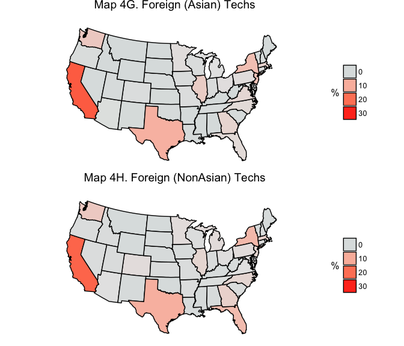

[back-to-top](https://archimedes2kxx.github.io/BestStatesForBlackTech/Supplement-3.html)

**Tables 4G and 4H … 50 states plus DC**  
Two data tables impose numeric precision on the qualitative insights provided by the corresponding maps. The tables are ordered by the number of techs from Asian countries or from non-Asian countries that worked in each state. The short versions of the tables that only contain the top ten rows are displayed below. To view the full tables that contain data for all 50 states plus the District of Columbia, please click the link below the table name. Each table (full and short versions) has the following five columns:

1. **State** – State of workplace for Asian or non-Asian techs
2. **AllForeign** – The total number of all foreign techs in the U.S. (Asian + non-Asian) who worked in each state. The data in this column is repeated in both tables, but the order of the rows differs from one table to the next. For example, Table 4G shows that the total number of foreign techs who worked California in 2015 was 127,671. Table 4H shows that total number of foreign techs in Florida was 23,049.
3. **perSS** – The state’s share of all Asian or non-Asian techs in the U.S. For example, Table 4G shows that 22.9 percent of the techs from Asian countries worked in California; and 9.3 percent of the techs from Asian countries worked in Texas.
4. **Asian/Non-Asian** The data in this column shows the number of Asian or non-Asian techs in each state. For example, Table 4H shows that 34,498 techs from non-Asian countries worked in California, and 5,342 techs from non-Asian countries worked in Illinois. The rows of each table are ordered by the data in this column, i.e., by the number of techs in each state. States with higher numbers are at the top of the table; states with lower numbers are at the bottom.
5. **perT** – Percent of all foreign techs in each state who were from Asian countries (Table 4G) or were from non-Asian countries (Table 4H). For example, Table 4G shows that 73 percent of the foreign techs in California were from from Asian countries. Table 4H shows that 27 percent of the foreign techs in California were from non-Asian countries.

[back-to-top](https://archimedes2kxx.github.io/BestStatesForBlackTech/Supplement-3.html)

The tables confirm the patterns displayed by the maps:

- The top ten states for foreign techs from Asian countries, Table 4G, were the same states as the top ten for foreign techs from non-Asian countries, Table 4H.
- Florida and Virginia are exceptions to this pattern. Virginia was among the top ten states for foreign techs from Asian countries; whereas Florida was among the top ten states for foreign techs from non-Asian countries in each state, Tables 4G and 4H.
- Otherwise the tables are remarkably similar. Indeed, the concentrations of techs from Asian countries was close to the concentrations of techs from non-Asian countries, i.e., high concentrations in California followed by much lower percentages in the other states as shown in the “perSS” columns of both tables

**Table 4G – Foreign Asian Professionals in U.S. Information Technology – Top 10 States**  
*Click here for full version*

```
          State AllForeign perSS   Asian perAsian
     ALL STATES    569,714 100.0 407,481     71.5
     California    127,671  22.9  93,173     73.0
          Texas     52,885   9.3  37,986     71.8
       New York     42,075   7.2  29,212     69.4
     New Jersey     31,859   6.5  26,443     83.0
     Washington     31,201   5.6  22,758     72.9
       Illinois     25,359   4.9  20,017     78.9
  Massachusetts     22,060   3.9  15,747     71.4
        Georgia     21,515   3.7  14,950     69.5
       Virginia     16,526   3.4  13,884     84.0
 North Carolina     16,699   2.8  11,457     68.6
```

[back-to-top](https://archimedes2kxx.github.io/BestStatesForBlackTech/Supplement-3.html)

**Table 4H – Foreign Non-Asian Professionals in U.S. Information Technology – Top 10 States**  
*Click here for full version*

```
          State AllForeign perSS NonAsian perNonAsian
     ALL STATES    569,714 100.0  162,233        28.5
     California    127,671  21.3   34,498        27.0
          Texas     52,885   9.2   14,899        28.2
       New York     42,075   7.9   12,863        30.6
        Florida     23,049   7.3   11,778        51.1
     Washington     31,201   5.2    8,443        27.1
        Georgia     21,515   4.0    6,565        30.5
  Massachusetts     22,060   3.9    6,313        28.6
     New Jersey     31,859   3.3    5,416        17.0
       Illinois     25,359   3.3    5,342        21.1
 North Carolina     16,699   3.2    5,242        31.4
```

[back-to-top](https://archimedes2kxx.github.io/BestStatesForBlackTech/Supplement-3.html)

## Final Comments

As per Table 3F.perFor (repeated below), the share of key jobs in the U.S. tech sector increased by small percentages between 2010 and 2015. Indeed these increases are so small that they might be offset by minor changes in hiring policies during the next five years, changes that would cause U.S. tech managers to hire fewer foreign professionals. But this is unlikely.

**Table 3F.perFor – Percentage of Key Jobs Held by Foreign Techs**

```
                    Occupation per2010 per2015
               All Occupations    11.4    12.3
           SOFTWARE DEVELOPERS    22.1    22.8
       DATABASE ADMINISTRATORS     8.9    12.4
 COMP/INFO RESEARCH SCIENTISTS    13.0    18.5
```

**California as U.S. Tech’s Exemplar State**  
Below find four labelled sections of a table like the four sections of Table 3 that appeared in answer to Question 3 in the text of this supplement. The difference is that these four sections focus on changes in American and foreign employment in the tech sector of the state of California.

**Rhetorical Question**  
How can the tech sectors in California and elsewhere employ higher and higher percentages of foreign techs … AND … become more diverse by employing larger percentages of Black and Hispanic techs?

**Table 3F.Cit.CA – Key Jobs for American Techs in California**

```
                    Occupation  Tech10  Tech15  Change perCh
               All Occupations 403,554 513,031 109,477  27.1
           SOFTWARE DEVELOPERS 103,979 154,590  50,611  48.7
       DATABASE ADMINISTRATORS   9,200   9,878     678   7.4
 COMP/INFO RESEARCH SCIENTISTS   1,935   2,164     229  11.8
```

**Table 3F.For.CA – Key Jobs for Foreign Techs in California**

```
                    Occupation Tech10  Tech15 Change perCh
               All Occupations 88,122 127,671 39,549  44.9
           SOFTWARE DEVELOPERS 47,252  74,399 27,147  57.5
       DATABASE ADMINISTRATORS    517   2,650  2,133 412.6
 COMP/INFO RESEARCH SCIENTISTS    568     993    425  74.8
```

**Table 3F.Tot.CA – Combined Total of Key Jobs Held by American and Foreign Techs in California**

```
                    Occupation  Tech10  Tech15
               All Occupations 491,676 640,702
           SOFTWARE DEVELOPERS 151,231 228,989
       DATABASE ADMINISTRATORS   9,717  12,528
 COMP/INFO RESEARCH SCIENTISTS   2,503   3,157
```

**Table 3F.perFor.CA – Percentage of Key Jobs Held by Foreign Techs in California**

```
                    Occupation per2010 per2015
               All Occupations    17.9    19.9
           SOFTWARE DEVELOPERS    31.2    32.5
       DATABASE ADMINISTRATORS     5.3    21.2
 COMP/INFO RESEARCH SCIENTISTS    22.7    31.5
```

[back-to-top](https://archimedes2kxx.github.io/BestStatesForBlackTech/Supplement-3.html)

## Personal Motivation

In the [“**Personal Motivation**”](https://archimedes2kxx.github.io/BestStatesForBlackTech/Report-3.html#personal-motivation) section of my original report, I noted that as DLL Editor I was driven to produce my report because of my dissatisfaction with the diversity reports that had been issued by major U.S. tech firms in the last three years. I stated that “What concerned me the most was the lack of context for assessing Silicon Valley’s diversity numbers. Were they as good as could be expected? Were they worse? … And compared to what?”

By completing this supplement, I have answered my own questions. Left to their own devices, I believe that for the foreseeable future the managers of U.S. tech in California and elsewhere will probably continue to produce annual reports that document their failure to substantially increase the percentage of Black and Hispanic professionals on their payrolls. Of course, the operative phrase is the lead-in, “Left to their own devices …” Sometime in the next few months, I will publish an op-ed on this blog that will propose a few strategies for correcting this continuing market failure … :-)

[back-to-top](https://archimedes2kxx.github.io/BestStatesForBlackTech/Supplement-3.html)

## Methods

The same methods that were used to collect and analyze the data for original report were used to produce this supplement. The reader is therefore referred to the original report’s [**descriptions of these methods**](https://archimedes2kxx.github.io/BestStatesForBlackTech/Report-3.html#methods). Two points from the original report bear repeating here:

- First, the report and this supplement were both designed to be “reproducible” – which means that the author has endeavored to provide all of the information that interested readers would require to reproduce the tables, charts, maps, and other components of the author’s findings on their own computers. Therefore copies of the computer programs that were used to create all of the components of this supplement have been placed on a [**GitHub repository**](https://github.com/Archimedes2kxx/BestStatesForBlackTech) that is accessible to the public. The repo also includes step-by-step descriptions of the procedures the author used to download the raw data from the online data servers maintained by the U.S. Census Bureau plus coding guides and other useful notes. (*Note that this repo also contains the files for the original report*)
- Second, the supplement document is found in the “Supplement-3.Rmd” file on the repo. The R functions that were used to analyze and transform the data are stored in the “functions-0.R” file. The R scripts in the “Data-1.R” file use these functions to download the data and create the data frames used by other scripts. The R scripts in the “Stats-2A” and “Stats-2B” use the functions to convert the data frames into the tables that are published in the “Supplement.Rmd” file.

[back-to-top](https://archimedes2kxx.github.io/BestStatesForBlackTech/Supplement-3.html)

## Appendix – Job Profiles of Foreign Techs in Six States that Hired the Most Foreign Techs in 2015

As per Table 4.1 in the supplement, the six states in this appendix employed the largest number of foreign professionals in their tech sectors – California, Texas, New York, New Jersey, Washington, and Illinois. This appendix displays job profiles of the foreign techs employed by each of these states. Two pairs of tables are included for each state.

- The first pair of tables displays job profiles of all foreign techs; the second pair displays job profiles for foreign techs from Asia
- The first table in each pair shows the distribution of foreign techs in the 13 job catebories in 2015; the second table in each pair shows the growth or changes foreign tech employment in each job category between 2010 and 2015.

In a future version of the supplement, this Appendix will be replaced by an interactive dashboard that will allow users to display pairs of tables for any state and for any American or foreign group.

*Note: The column headings and abbreviated row names of the tables in this appendix are explained in the answer to [**Question 3**](https://archimedes2kxx.github.io/BestStatesForBlackTech/Supplement-3.html#question-3-how-did-the-foreign-shares-of-jobs-in-u.s.-tech-change-between-2010-and-2015) in the body of the supplement*

### California … California …California … California … California …

**Table 3.forCA – Foreign Male/Female Composition of Tech in California in 2015**

```
                     Occupation perTS  Tech15    Fem perF15
                All Occupations 100.0 127,671 24,602   19.3
            SOFTWARE DEVELOPERS  58.3  74,399 13,827   18.6
           COMPUTER PROGRAMMERS   9.1  11,596  3,140   27.1
      COMPUTER SYSTEMS ANALYSTS   6.9   8,790  1,814   20.6
 COMPUTER/INFO SYSTEMS MANAGERS   6.0   7,615  1,815   23.8
 COMPUTER OCCUPATIONS ALL OTHER   5.3   6,820    454    6.7
   COMPUTER SUPPORT SPECIALISTS   4.1   5,244    882   16.8
    COMPUTER HARDWARE ENGINEERS   2.4   3,007    874   29.1
        DATABASE ADMINISTRATORS   2.1   2,650    619   23.4
    COMPUTER NETWORK ARCHITECTS   1.9   2,458    137    5.6
    NETWORK/COMP SYSTEMS ADMINS   1.7   2,149    311   14.5
                 WEB DEVELOPERS   1.4   1,760    589   33.5
  COMP/INFO RESEARCH SCIENTISTS   0.8     993     67    6.7
  INFORMATION SECURITY ANALYSTS   0.1     190     73   38.4
```

**Table 3.forCACA – Changes in the Foreign Composition of Tech In California between 2010 and 2015**

```
                     Occupation Tech10  Tech15 Change perCh perF10
                All Occupations 88,122 127,671 39,549  44.9   21.8
            SOFTWARE DEVELOPERS 47,252  74,399 27,147  57.5   21.6
           COMPUTER PROGRAMMERS  7,477  11,596  4,119  55.1   25.7
      COMPUTER SYSTEMS ANALYSTS 10,039   8,790 -1,249 -12.4   25.7
 COMPUTER/INFO SYSTEMS MANAGERS  6,376   7,615  1,239  19.4   22.9
 COMPUTER OCCUPATIONS ALL OTHER  2,399   6,820  4,421 184.3    9.8
   COMPUTER SUPPORT SPECIALISTS  3,999   5,244  1,245  31.1   15.3
    COMPUTER HARDWARE ENGINEERS  1,857   3,007  1,150  61.9   21.4
        DATABASE ADMINISTRATORS    517   2,650  2,133 412.6   29.6
    COMPUTER NETWORK ARCHITECTS  2,421   2,458     37   1.5   10.6
    NETWORK/COMP SYSTEMS ADMINS  1,904   2,149    245  12.9   15.6
                 WEB DEVELOPERS  3,053   1,760 -1,293 -42.4   29.8
  COMP/INFO RESEARCH SCIENTISTS    568     993    425  74.8   22.7
  INFORMATION SECURITY ANALYSTS    260     190    -70 -26.9    0.0
```

[back-to-top](https://archimedes2kxx.github.io/BestStatesForBlackTech/Supplement-3.html)

**Table 3.forAsianCA – Foreign Asian Male/Female Composition of Tech in California in 2015**

```
                     Occupation perTS Tech15    Fem perF15
                All Occupations 100.0 93,173 21,632   23.2
            SOFTWARE DEVELOPERS  63.4 59,061 12,890   21.8
           COMPUTER PROGRAMMERS   8.0  7,445  2,836   38.1
      COMPUTER SYSTEMS ANALYSTS   7.2  6,726  1,617   24.0
 COMPUTER/INFO SYSTEMS MANAGERS   4.7  4,378  1,240   28.3
 COMPUTER OCCUPATIONS ALL OTHER   4.7  4,362    417    9.6
   COMPUTER SUPPORT SPECIALISTS   3.4  3,137    458   14.6
        DATABASE ADMINISTRATORS   2.0  1,873    619   33.0
    COMPUTER HARDWARE ENGINEERS   2.0  1,825    568   31.1
                 WEB DEVELOPERS   1.7  1,614    589   36.5
    COMPUTER NETWORK ARCHITECTS   1.4  1,284    137   10.7
  COMP/INFO RESEARCH SCIENTISTS   0.9    826     67    8.1
    NETWORK/COMP SYSTEMS ADMINS   0.5    507    121   23.9
  INFORMATION SECURITY ANALYSTS   0.1    135     73   54.1
```

**Table 3.forAsianCACA – Changes in the Foreign Asian Composition of Tech In California between 2010 and 2015**

```
                     Occupation Tech10 Tech15 Change perCh perF10
                All Occupations 64,508 93,173 28,665  44.4   22.9
            SOFTWARE DEVELOPERS 37,811 59,061 21,250  56.2   22.7
           COMPUTER PROGRAMMERS  5,403  7,445  2,042  37.8   26.1
      COMPUTER SYSTEMS ANALYSTS  6,737  6,726    -11  -0.2   21.2
 COMPUTER/INFO SYSTEMS MANAGERS  4,456  4,378    -78  -1.8   28.7
 COMPUTER OCCUPATIONS ALL OTHER    938  4,362  3,424 365.0   18.6
   COMPUTER SUPPORT SPECIALISTS  2,710  3,137    427  15.8   12.3
        DATABASE ADMINISTRATORS    276  1,873  1,597 578.6   22.8
    COMPUTER HARDWARE ENGINEERS  1,349  1,825    476  35.3   25.3
                 WEB DEVELOPERS  1,701  1,614    -87  -5.1   53.4
    COMPUTER NETWORK ARCHITECTS  1,619  1,284   -335 -20.7    3.5
  COMP/INFO RESEARCH SCIENTISTS    344    826    482 140.1   37.5
    NETWORK/COMP SYSTEMS ADMINS    904    507   -397 -43.9    6.1
  INFORMATION SECURITY ANALYSTS    260    135   -125 -48.1    0.0
```

[back-to-top](https://archimedes2kxx.github.io/BestStatesForBlackTech/Supplement-3.html)

### Texas … Texas … Texas … Texas … Texas … Texas … Texas …

**Table 3.forTX – Foreign Male/Female Composition of Tech in Texas in 2015**

```
                     Occupation perTS Tech15    Fem perF15
                All Occupations 100.0 52,885 11,968   22.6
            SOFTWARE DEVELOPERS  38.7 20,448  4,226   20.7
 COMPUTER/INFO SYSTEMS MANAGERS  11.1  5,880  1,154   19.6
           COMPUTER PROGRAMMERS  10.3  5,440    716   13.2
      COMPUTER SYSTEMS ANALYSTS   9.9  5,223  1,121   21.5
   COMPUTER SUPPORT SPECIALISTS   9.0  4,770    773   16.2
 COMPUTER OCCUPATIONS ALL OTHER   8.7  4,613  1,810   39.2
    COMPUTER NETWORK ARCHITECTS   3.6  1,909    502   26.3
    NETWORK/COMP SYSTEMS ADMINS   2.8  1,485    597   40.2
        DATABASE ADMINISTRATORS   2.0  1,046    329   31.5
                 WEB DEVELOPERS   1.7    885    237   26.8
  INFORMATION SECURITY ANALYSTS   1.3    673    387   57.5
    COMPUTER HARDWARE ENGINEERS   0.8    399    116   29.1
  COMP/INFO RESEARCH SCIENTISTS   0.2    114      0    0.0
```

**Table 3.forTXTX – Changes in the Foreign Composition of Tech In Texas between 2010 and 2015**

```
                     Occupation Tech10 Tech15 Change perCh perF10
                All Occupations 36,327 52,885 16,558  45.6   26.7
            SOFTWARE DEVELOPERS 13,777 20,448  6,671  48.4   23.3
 COMPUTER/INFO SYSTEMS MANAGERS  2,648  5,880  3,232 122.1   26.4
           COMPUTER PROGRAMMERS  3,893  5,440  1,547  39.7   44.0
      COMPUTER SYSTEMS ANALYSTS  4,361  5,223    862  19.8   28.8
   COMPUTER SUPPORT SPECIALISTS  3,215  4,770  1,555  48.4   22.9
 COMPUTER OCCUPATIONS ALL OTHER  2,442  4,613  2,171  88.9   21.8
    COMPUTER NETWORK ARCHITECTS  1,208  1,909    701  58.0   26.7
    NETWORK/COMP SYSTEMS ADMINS  1,073  1,485    412  38.4   26.7
        DATABASE ADMINISTRATORS    816  1,046    230  28.2    8.9
                 WEB DEVELOPERS    265    885    620 234.0   38.5
  INFORMATION SECURITY ANALYSTS    169    673    504 298.2    0.0
    COMPUTER HARDWARE ENGINEERS  1,818    399 -1,419 -78.1   37.1
  COMP/INFO RESEARCH SCIENTISTS    642    114   -528 -82.2   12.8
```

[back-to-top](https://archimedes2kxx.github.io/BestStatesForBlackTech/Supplement-3.html)

**Table 3.forAsianTX – Foreign Asian Male/Female Composition of Tech in Texas in 2015**

```
                     Occupation perTS Tech15   Fem perF15
                All Occupations 100.0 37,986 9,038   23.8
            SOFTWARE DEVELOPERS  45.8 17,385 3,814   21.9
           COMPUTER PROGRAMMERS  12.4  4,709   716   15.2
      COMPUTER SYSTEMS ANALYSTS   9.7  3,666   739   20.2
 COMPUTER/INFO SYSTEMS MANAGERS   9.3  3,536   359   10.2
 COMPUTER OCCUPATIONS ALL OTHER   8.4  3,191 1,414   44.3
   COMPUTER SUPPORT SPECIALISTS   4.8  1,838   661   36.0
    COMPUTER NETWORK ARCHITECTS   3.0  1,147   502   43.8
        DATABASE ADMINISTRATORS   2.4    927   210   22.7
  INFORMATION SECURITY ANALYSTS   1.4    548   387   70.6
    NETWORK/COMP SYSTEMS ADMINS   1.4    517    73   14.1
    COMPUTER HARDWARE ENGINEERS   0.7    270   116   43.0
                 WEB DEVELOPERS   0.4    138    47   34.1
  COMP/INFO RESEARCH SCIENTISTS   0.3    114     0    0.0
```

**Table 3.forAsianTXTX – Changes in the Foreign Asian Composition of Tech In Texas between 2010 and 2015**

```
                     Occupation Tech10 Tech15 Change perCh perF10
                All Occupations 26,229 37,986 11,757  44.8   28.1
            SOFTWARE DEVELOPERS 10,991 17,385  6,394  58.2   22.8
           COMPUTER PROGRAMMERS  2,409  4,709  2,300  95.5   53.6
      COMPUTER SYSTEMS ANALYSTS  3,821  3,666   -155  -4.1   30.7
 COMPUTER/INFO SYSTEMS MANAGERS  1,383  3,536  2,153 155.7   14.5
 COMPUTER OCCUPATIONS ALL OTHER  1,369  3,191  1,822 133.1   24.3
   COMPUTER SUPPORT SPECIALISTS  2,234  1,838   -396 -17.7   24.1
    COMPUTER NETWORK ARCHITECTS    945  1,147    202  21.4   34.2
        DATABASE ADMINISTRATORS    561    927    366  65.2   13.0
  INFORMATION SECURITY ANALYSTS     69    548    479 694.2    0.0
    NETWORK/COMP SYSTEMS ADMINS    385    517    132  34.3   36.6
    COMPUTER HARDWARE ENGINEERS  1,450    270 -1,180 -81.4   46.6
                 WEB DEVELOPERS    102    138     36  35.3  100.0
  COMP/INFO RESEARCH SCIENTISTS    510    114   -396 -77.6    0.0
```

[back-to-top](https://archimedes2kxx.github.io/BestStatesForBlackTech/Supplement-3.html)

### New York … New York … New York … New York …

**Table 3.forNY – Foreign Male/Female Composition of Tech in New York in 2015**

```
                     Occupation perTS Tech15   Fem perF15
                All Occupations 100.0 42,075 7,949   18.9
            SOFTWARE DEVELOPERS  39.6 16,664 2,314   13.9
   COMPUTER SUPPORT SPECIALISTS  10.4  4,370 1,434   32.8
 COMPUTER OCCUPATIONS ALL OTHER  10.1  4,248   880   20.7
 COMPUTER/INFO SYSTEMS MANAGERS   9.5  3,989   324    8.1
           COMPUTER PROGRAMMERS   9.4  3,963   816   20.6
      COMPUTER SYSTEMS ANALYSTS   8.9  3,755 1,107   29.5
                 WEB DEVELOPERS   3.7  1,576   465   29.5
        DATABASE ADMINISTRATORS   3.0  1,260   556   44.1
    COMPUTER NETWORK ARCHITECTS   1.7    725     0    0.0
    NETWORK/COMP SYSTEMS ADMINS   1.4    580     0    0.0
  COMP/INFO RESEARCH SCIENTISTS   1.0    441    53   12.0
    COMPUTER HARDWARE ENGINEERS   0.7    281     0    0.0
  INFORMATION SECURITY ANALYSTS   0.5    223     0    0.0
```

**Table 3.forNYNY – Changes in the Foreign Composition of Tech In New York between 2010 and 2015**

```
                     Occupation Tech10 Tech15 Change perCh perF10
                All Occupations 35,337 42,075  6,738  19.1   18.6
            SOFTWARE DEVELOPERS 10,477 16,664  6,187  59.1   12.8
   COMPUTER SUPPORT SPECIALISTS  2,888  4,370  1,482  51.3   27.9
 COMPUTER OCCUPATIONS ALL OTHER  2,140  4,248  2,108  98.5   22.3
 COMPUTER/INFO SYSTEMS MANAGERS  3,778  3,989    211   5.6   14.6
           COMPUTER PROGRAMMERS  5,226  3,963 -1,263 -24.2   11.6
      COMPUTER SYSTEMS ANALYSTS  5,466  3,755 -1,711 -31.3   28.7
                 WEB DEVELOPERS    776  1,576    800 103.1   23.6
        DATABASE ADMINISTRATORS  1,280  1,260    -20  -1.6   18.0
    COMPUTER NETWORK ARCHITECTS    677    725     48   7.1   45.6
    NETWORK/COMP SYSTEMS ADMINS  1,563    580   -983 -62.9   24.0
  COMP/INFO RESEARCH SCIENTISTS    195    441    246 126.2    0.0
    COMPUTER HARDWARE ENGINEERS    871    281   -590 -67.7   16.4
  INFORMATION SECURITY ANALYSTS      0    223    223   Inf    0.0
```

[back-to-top](https://archimedes2kxx.github.io/BestStatesForBlackTech/Supplement-3.html)

**Table 3.forAsianNY – Foreign Asian Male/Female Composition of Tech in New York in 2015**

```
                     Occupation perTS Tech15   Fem perF15
                All Occupations 100.0 29,212 5,916   20.3
            SOFTWARE DEVELOPERS  46.9 13,695 1,982   14.5
      COMPUTER SYSTEMS ANALYSTS  10.6  3,101   605   19.5
           COMPUTER PROGRAMMERS   9.7  2,820   638   22.6
 COMPUTER OCCUPATIONS ALL OTHER   8.1  2,370   880   37.1
   COMPUTER SUPPORT SPECIALISTS   8.1  2,363 1,252   53.0
 COMPUTER/INFO SYSTEMS MANAGERS   7.8  2,266   118    5.2
        DATABASE ADMINISTRATORS   2.6    746   278   37.3
                 WEB DEVELOPERS   1.9    567   163   28.7
  COMP/INFO RESEARCH SCIENTISTS   1.3    388     0    0.0
    COMPUTER NETWORK ARCHITECTS   1.2    364     0    0.0
    COMPUTER HARDWARE ENGINEERS   1.0    281     0    0.0
    NETWORK/COMP SYSTEMS ADMINS   0.9    251     0    0.0
  INFORMATION SECURITY ANALYSTS   0.0      0     0    0.0
```

**Table 3.forAsianNYNY – Changes in the Foreign Asian Composition of Tech In New York between 2010 and 2015**

```
                     Occupation Tech10 Tech15 Change perCh perF10
                All Occupations 21,802 29,212  7,410  34.0   17.5
            SOFTWARE DEVELOPERS  7,431 13,695  6,264  84.3   14.7
      COMPUTER SYSTEMS ANALYSTS  3,309  3,101   -208  -6.3   25.4
           COMPUTER PROGRAMMERS  3,451  2,820   -631 -18.3   17.5
 COMPUTER OCCUPATIONS ALL OTHER    879  2,370  1,491 169.6   46.5
   COMPUTER SUPPORT SPECIALISTS  1,099  2,363  1,264 115.0    0.0
 COMPUTER/INFO SYSTEMS MANAGERS  1,706  2,266    560  32.8   18.7
        DATABASE ADMINISTRATORS  1,215    746   -469 -38.6   13.6
                 WEB DEVELOPERS    287    567    280  97.6    0.0
  COMP/INFO RESEARCH SCIENTISTS    135    388    253 187.4    0.0
    COMPUTER NETWORK ARCHITECTS    609    364   -245 -40.2   39.6
    COMPUTER HARDWARE ENGINEERS    756    281   -475 -62.8   18.9
    NETWORK/COMP SYSTEMS ADMINS    925    251   -674 -72.9    0.0
  INFORMATION SECURITY ANALYSTS      0      0      0   NaN    0.0
```

[back-to-top](https://archimedes2kxx.github.io/BestStatesForBlackTech/Supplement-3.html)

### New Jersey … New Jersey … New Jersey …

**Table 3.forNJ – Foreign Male/Female Composition of Tech in New Jersey in 2015**

```
                     Occupation perTS Tech15   Fem perF15
                All Occupations 100.0 31,859 6,717   21.1
            SOFTWARE DEVELOPERS  39.1 12,469 1,784   14.3
 COMPUTER/INFO SYSTEMS MANAGERS  15.1  4,797 1,066   22.2
 COMPUTER OCCUPATIONS ALL OTHER  14.0  4,445 1,463   32.9
      COMPUTER SYSTEMS ANALYSTS  10.8  3,426   534   15.6
           COMPUTER PROGRAMMERS   7.5  2,398   462   19.3
   COMPUTER SUPPORT SPECIALISTS   7.5  2,385   678   28.4
    NETWORK/COMP SYSTEMS ADMINS   1.8    559    77   13.8
    COMPUTER NETWORK ARCHITECTS   1.2    395   146   37.0
                 WEB DEVELOPERS   1.2    383   298   77.8
        DATABASE ADMINISTRATORS   1.1    346   209   60.4
    COMPUTER HARDWARE ENGINEERS   0.8    256     0    0.0
  COMP/INFO RESEARCH SCIENTISTS   0.0      0     0    0.0
  INFORMATION SECURITY ANALYSTS   0.0      0     0    0.0
```

**Table 3.forNJNJ – Changes in the Foreign Composition of Tech In New Jersey between 2010 and 2015**

```
                     Occupation Tech10 Tech15 Change  perCh perF10
                All Occupations 25,463 31,859  6,396   25.1   18.2
            SOFTWARE DEVELOPERS 10,385 12,469  2,084   20.1   16.4
 COMPUTER/INFO SYSTEMS MANAGERS  2,288  4,797  2,509  109.7   22.6
 COMPUTER OCCUPATIONS ALL OTHER  1,218  4,445  3,227  264.9   19.1
      COMPUTER SYSTEMS ANALYSTS  3,291  3,426    135    4.1   17.9
           COMPUTER PROGRAMMERS  3,987  2,398 -1,589  -39.9   28.6
   COMPUTER SUPPORT SPECIALISTS    971  2,385  1,414  145.6   11.4
    NETWORK/COMP SYSTEMS ADMINS  1,502    559   -943  -62.8   11.7
    COMPUTER NETWORK ARCHITECTS    464    395    -69  -14.9    0.0
                 WEB DEVELOPERS    765    383   -382  -49.9    0.0
        DATABASE ADMINISTRATORS    198    346    148   74.7   47.5
    COMPUTER HARDWARE ENGINEERS    248    256      8    3.2    0.0
  COMP/INFO RESEARCH SCIENTISTS     64      0    -64 -100.0    0.0
  INFORMATION SECURITY ANALYSTS     82      0    -82 -100.0  100.0
```

[back-to-top](https://archimedes2kxx.github.io/BestStatesForBlackTech/Supplement-3.html)

**Table 3.forAsianNJ – Foreign Asian Male/Female Composition of Tech in New Jersey in 2015**

```
                     Occupation perTS Tech15   Fem perF15
                All Occupations 100.0 26,443 5,844   22.1
            SOFTWARE DEVELOPERS  43.3 11,437 1,690   14.8
 COMPUTER OCCUPATIONS ALL OTHER  12.2  3,239 1,386   42.8
 COMPUTER/INFO SYSTEMS MANAGERS  11.9  3,145   923   29.3
      COMPUTER SYSTEMS ANALYSTS  11.3  2,992   215    7.2
   COMPUTER SUPPORT SPECIALISTS   7.9  2,091   661   31.6
           COMPUTER PROGRAMMERS   7.8  2,075   417   20.1
    COMPUTER NETWORK ARCHITECTS   1.5    395   146   37.0
                 WEB DEVELOPERS   1.4    383   298   77.8
    COMPUTER HARDWARE ENGINEERS   1.0    256     0    0.0
        DATABASE ADMINISTRATORS   0.9    245   108   44.1
    NETWORK/COMP SYSTEMS ADMINS   0.7    185     0    0.0
  COMP/INFO RESEARCH SCIENTISTS   0.0      0     0    0.0
  INFORMATION SECURITY ANALYSTS   0.0      0     0    0.0
```

**Table 3.forAsianNJNJ – Changes in the Foreign Asian Composition of Tech In New Jersey between 2010 and 2015**

```
                     Occupation Tech10 Tech15 Change perCh perF10
                All Occupations 20,182 26,443  6,261  31.0   19.3
            SOFTWARE DEVELOPERS  9,339 11,437  2,098  22.5   18.2
 COMPUTER OCCUPATIONS ALL OTHER    421  3,239  2,818 669.4   21.1
 COMPUTER/INFO SYSTEMS MANAGERS  1,868  3,145  1,277  68.4   21.6
      COMPUTER SYSTEMS ANALYSTS  2,779  2,992    213   7.7   21.2
   COMPUTER SUPPORT SPECIALISTS    366  2,091  1,725 471.3   30.3
           COMPUTER PROGRAMMERS  3,198  2,075 -1,123 -35.1   28.2
    COMPUTER NETWORK ARCHITECTS    402    395     -7  -1.7    0.0
                 WEB DEVELOPERS    695    383   -312 -44.9    0.0
    COMPUTER HARDWARE ENGINEERS    248    256      8   3.2    0.0
        DATABASE ADMINISTRATORS    198    245     47  23.7   47.5
    NETWORK/COMP SYSTEMS ADMINS    668    185   -483 -72.3    0.0
  COMP/INFO RESEARCH SCIENTISTS      0      0      0   NaN    0.0
  INFORMATION SECURITY ANALYSTS      0      0      0   NaN    0.0
```

[back-to-top](https://archimedes2kxx.github.io/BestStatesForBlackTech/Supplement-3.html)

### Washington … Washington …

**Table 3.forWA – Foreign Male/Female Composition of Tech in Washington in 2015**

```
                     Occupation perTS Tech15   Fem perF15
                All Occupations 100.0 31,201 5,112   16.4
            SOFTWARE DEVELOPERS  70.0 21,855 3,544   16.2
      COMPUTER SYSTEMS ANALYSTS   5.3  1,649   376   22.8
 COMPUTER/INFO SYSTEMS MANAGERS   4.9  1,518   103    6.8
   COMPUTER SUPPORT SPECIALISTS   4.3  1,328   421   31.7
           COMPUTER PROGRAMMERS   3.8  1,194    71    5.9
    COMPUTER NETWORK ARCHITECTS   3.3  1,029     0    0.0
 COMPUTER OCCUPATIONS ALL OTHER   2.9    901   222   24.6
    NETWORK/COMP SYSTEMS ADMINS   1.7    518   105   20.3
                 WEB DEVELOPERS   1.4    422     0    0.0
        DATABASE ADMINISTRATORS   1.0    324    54   16.7
  COMP/INFO RESEARCH SCIENTISTS   0.8    247     0    0.0
    COMPUTER HARDWARE ENGINEERS   0.7    216   216  100.0
  INFORMATION SECURITY ANALYSTS   0.0      0     0    0.0
```

**Table 3.forWAWA – Changes in the Foreign Composition of Tech In Washington between 2010 and 2015**

```
                     Occupation Tech10 Tech15 Change perCh perF10
                All Occupations 25,883 31,201  5,318  20.5   19.3
            SOFTWARE DEVELOPERS 18,305 21,855  3,550  19.4   20.4
      COMPUTER SYSTEMS ANALYSTS  2,478  1,649   -829 -33.5   18.5
 COMPUTER/INFO SYSTEMS MANAGERS  1,831  1,518   -313 -17.1   11.9
   COMPUTER SUPPORT SPECIALISTS    538  1,328    790 146.8   14.3
           COMPUTER PROGRAMMERS    796  1,194    398  50.0   25.8
    COMPUTER NETWORK ARCHITECTS    102  1,029    927 908.8    0.0
 COMPUTER OCCUPATIONS ALL OTHER    794    901    107  13.5   12.7
    NETWORK/COMP SYSTEMS ADMINS    482    518     36   7.5    0.0
                 WEB DEVELOPERS    119    422    303 254.6   11.8
        DATABASE ADMINISTRATORS    110    324    214 194.5    0.0
  COMP/INFO RESEARCH SCIENTISTS    328    247    -81 -24.7   54.0
    COMPUTER HARDWARE ENGINEERS      0    216    216   Inf    0.0
  INFORMATION SECURITY ANALYSTS      0      0      0   NaN    0.0
```

[back-to-top](https://archimedes2kxx.github.io/BestStatesForBlackTech/Supplement-3.html)

**Table 3.forAsianWA – Foreign Asian Male/Female Composition of Tech in Washington in 2015**

```
                     Occupation perTS Tech15   Fem perF15
                All Occupations 100.0 22,758 4,236   18.6
            SOFTWARE DEVELOPERS  73.1 16,627 3,222   19.4
 COMPUTER/INFO SYSTEMS MANAGERS   5.6  1,284     0    0.0
      COMPUTER SYSTEMS ANALYSTS   4.6  1,058   376   35.5
           COMPUTER PROGRAMMERS   4.0    920    71    7.7
   COMPUTER SUPPORT SPECIALISTS   3.2    726   207   28.5
    COMPUTER NETWORK ARCHITECTS   3.1    710     0    0.0
 COMPUTER OCCUPATIONS ALL OTHER   2.2    501    92   18.4
        DATABASE ADMINISTRATORS   1.2    268    54   20.1
  COMP/INFO RESEARCH SCIENTISTS   1.1    247     0    0.0
                 WEB DEVELOPERS   0.9    203     0    0.0
    COMPUTER HARDWARE ENGINEERS   0.5    109   109  100.0
    NETWORK/COMP SYSTEMS ADMINS   0.5    105   105  100.0
  INFORMATION SECURITY ANALYSTS   0.0      0     0    0.0
```

**Table 3.forAsianWAWA – Changes in the Foreign Asian Composition of Tech In Washington between 2010 and 2015**

```
                     Occupation Tech10 Tech15 Change perCh perF10
                All Occupations 16,889 22,758  5,869  34.8   24.4
            SOFTWARE DEVELOPERS 12,952 16,627  3,675  28.4   24.7
 COMPUTER/INFO SYSTEMS MANAGERS  1,069  1,284    215  20.1   20.4
      COMPUTER SYSTEMS ANALYSTS  1,929  1,058   -871 -45.2   23.7
           COMPUTER PROGRAMMERS    288    920    632 219.4   22.9
   COMPUTER SUPPORT SPECIALISTS    174    726    552 317.2   44.3
    COMPUTER NETWORK ARCHITECTS      0    710    710   Inf    0.0
 COMPUTER OCCUPATIONS ALL OTHER    260    501    241  92.7   38.8
        DATABASE ADMINISTRATORS      0    268    268   Inf    0.0
  COMP/INFO RESEARCH SCIENTISTS      0    247    247   Inf    0.0
                 WEB DEVELOPERS      0    203    203   Inf    0.0
    COMPUTER HARDWARE ENGINEERS      0    109    109   Inf    0.0
    NETWORK/COMP SYSTEMS ADMINS    217    105   -112 -51.6    0.0
  INFORMATION SECURITY ANALYSTS      0      0      0   NaN    0.0
```

[back-to-top](https://archimedes2kxx.github.io/BestStatesForBlackTech/Supplement-3.html)

### Illinois … Illinois …

**Table 3.forIL – Foreign Male/Female Composition of Tech in Illinois in 2015**

```
                     Occupation perTS Tech15   Fem perF15
                All Occupations 100.0 25,359 5,773   22.8
            SOFTWARE DEVELOPERS  45.0 11,406 2,942   25.8
      COMPUTER SYSTEMS ANALYSTS  12.0  3,040   989   32.5
 COMPUTER/INFO SYSTEMS MANAGERS  11.4  2,893   167    5.8
 COMPUTER OCCUPATIONS ALL OTHER   9.1  2,311   642   27.8
           COMPUTER PROGRAMMERS   5.9  1,496   443   29.6
   COMPUTER SUPPORT SPECIALISTS   5.6  1,408   160   11.4
        DATABASE ADMINISTRATORS   3.3    849   360   42.4
    NETWORK/COMP SYSTEMS ADMINS   2.3    583     0    0.0
                 WEB DEVELOPERS   2.3    581    70   12.0
    COMPUTER HARDWARE ENGINEERS   1.4    365     0    0.0
    COMPUTER NETWORK ARCHITECTS   0.9    236     0    0.0
  COMP/INFO RESEARCH SCIENTISTS   0.8    191     0    0.0
  INFORMATION SECURITY ANALYSTS   0.0      0     0    0.0
```

**Table 3.forILIL – Changes in the Foreign Composition of Tech In Illinois between 2010 and 2015**

```
                     Occupation Tech10 Tech15 Change  perCh perF10
                All Occupations 19,943 25,359  5,416   27.2   24.3
            SOFTWARE DEVELOPERS  7,082 11,406  4,324   61.1   31.9
      COMPUTER SYSTEMS ANALYSTS  4,221  3,040 -1,181  -28.0   28.0
 COMPUTER/INFO SYSTEMS MANAGERS  2,463  2,893    430   17.5   23.4
 COMPUTER OCCUPATIONS ALL OTHER    650  2,311  1,661  255.5   18.6
           COMPUTER PROGRAMMERS  2,338  1,496   -842  -36.0   22.1
   COMPUTER SUPPORT SPECIALISTS    887  1,408    521   58.7    9.5
        DATABASE ADMINISTRATORS    158    849    691  437.3    0.0
    NETWORK/COMP SYSTEMS ADMINS    308    583    275   89.3    0.0
                 WEB DEVELOPERS    479    581    102   21.3   22.1
    COMPUTER HARDWARE ENGINEERS    255    365    110   43.1    0.0
    COMPUTER NETWORK ARCHITECTS  1,019    236   -783  -76.8    0.0
  COMP/INFO RESEARCH SCIENTISTS      0    191    191    Inf    0.0
  INFORMATION SECURITY ANALYSTS     83      0    -83 -100.0    0.0
```

[back-to-top](https://archimedes2kxx.github.io/BestStatesForBlackTech/Supplement-3.html)

**Table 3.forAsianIL – Foreign Asian Male/Female Composition of Tech in Illinois in 2015**

```
                     Occupation perTS Tech15   Fem perF15
                All Occupations 100.0 20,017 5,124   25.6
            SOFTWARE DEVELOPERS  49.1  9,823 2,715   27.6
      COMPUTER SYSTEMS ANALYSTS  14.7  2,948   897   30.4
 COMPUTER/INFO SYSTEMS MANAGERS   9.8  1,955     0    0.0
 COMPUTER OCCUPATIONS ALL OTHER   6.4  1,285   549   42.7
           COMPUTER PROGRAMMERS   5.3  1,059   443   41.8
   COMPUTER SUPPORT SPECIALISTS   5.0    998   160   16.0
        DATABASE ADMINISTRATORS   3.8    759   360   47.4
                 WEB DEVELOPERS   1.8    368     0    0.0
    COMPUTER NETWORK ARCHITECTS   1.2    236     0    0.0
    COMPUTER HARDWARE ENGINEERS   1.2    235     0    0.0
  COMP/INFO RESEARCH SCIENTISTS   1.0    191     0    0.0
    NETWORK/COMP SYSTEMS ADMINS   0.8    160     0    0.0
  INFORMATION SECURITY ANALYSTS   0.0      0     0    0.0
```

**Table 3.forAsianILIL – Changes in the Foreign Asian Composition of Tech In Illinois between 2010 and 2015**

```
                     Occupation Tech10 Tech15 Change perCh perF10
                All Occupations 15,924 20,017  4,093  25.7   27.8
            SOFTWARE DEVELOPERS  6,330  9,823  3,493  55.2   33.8
      COMPUTER SYSTEMS ANALYSTS  4,005  2,948 -1,057 -26.4   26.7
 COMPUTER/INFO SYSTEMS MANAGERS  1,565  1,955    390  24.9   32.1
 COMPUTER OCCUPATIONS ALL OTHER    447  1,285    838 187.5   27.1
           COMPUTER PROGRAMMERS  2,119  1,059 -1,060 -50.0   24.4
   COMPUTER SUPPORT SPECIALISTS    342    998    656 191.8   24.6
        DATABASE ADMINISTRATORS    158    759    601 380.4    0.0
                 WEB DEVELOPERS    373    368     -5  -1.3    0.0
    COMPUTER NETWORK ARCHITECTS    491    236   -255 -51.9    0.0
    COMPUTER HARDWARE ENGINEERS      0    235    235   Inf    0.0
  COMP/INFO RESEARCH SCIENTISTS      0    191    191   Inf    0.0
    NETWORK/COMP SYSTEMS ADMINS     94    160     66  70.2    0.0
  INFORMATION SECURITY ANALYSTS      0      0      0   NaN    0.0
```

[back-to-top](https://archimedes2kxx.github.io/BestStatesForBlackTech/Supplement-3.html)